# Why Did We Help Each Other?

Explaining Peer Support in Learning Social Networks Theory and Methods

Adam Talsma

December 2021

### Introduction

This social networks class involved online interaction among students and teachers as a key part of the learning process. We used Moodle then Slack to seek out and provide help in learning networks and R. Our teachers often helped, but we students also provided responses and helped each other. This project seeks to determine what explains who helped, and considers likely network and non-network factors as possible determinants.

### Theory

Education scholars theorize peers as effective co-constructors of learning [(Vygotsky, 1978)](https://www.hup.harvard.edu/catalog.php?isbn=9780674576292). Empirical studies have shown that online collaboration platforms, including Slack, can support peer learning in response to individual queries among graduate students [(Walker et al., 2021)](https://journal.alt.ac.uk/index.php/rlt/article/view/2520). Some prior studies contend that graduate students give knowledge in learning communities for four reasons: altruism, social trust, belonging [(Brouwer and Jansen, 2019)](https://www.tandfonline.com/doi/full/10.1080/07294360.2018.1522619), and cultural integration [(Sadykova 2014)](http://www.irrodl.org/index.php/irrodl/article/view/1629). This project leverages social network theory to consider new theoretical drivers; I propose that the *network structure* of the digital interactions between students may also explain their decisions to help.

### Data

The network data was mined from our class’s digital footprints in Moodle and Slack that were accessible to all of us. It is a multiplex network with two types of *directed ties*: 1) **online “helps”** of each time a student helped another student, and 2) **offline relationships** measured for two points in time: before the class and part-way through. The offline relationships data was gathered through a survey of all 24 students that also served to gather relevant attributes.

### Variables and Hypotheses

The **response variable** is *providing* help online.

The **network hypotheses** that I introduce as my main predictor variables are:

- $H_1$: *In-degree Centrality*: The more students receive help from peers, the more likely they are to “pass it on” by helping others.
- $H_2$: *Out-degree Centrality*: The more students help, the more likely they are to keep helping.

I test my hypotheses with proxies for the **theoretical controls** that the literature has identified.

- *Altruism*: Students that are more altruistic help other students more.
- *Social Trust*: Students who send more offline social ties will help more.
- *Belonging*: Students who have been at the Institute longer will help more.
- *Culture*: Students in their cultural environment will help more. I consider Local/International, European/Non-European and Global Northern/Southern.

I also considered a few **additional control variables**:

- *R Knowledge*: Students who know R should help more.
- *Difference in Learning style*: Students that prefer group-work should help more.
- *Gender*: Ambivalent, arguments for either gender helping more.
- *Popularity*: People with more in-degree offline ties should help online less.

### Network Statistics and Visualization

Let’s start off with a few class statistics: the average student helped over 5 times and has between 3 and 4 offline friendships. Most are altruistic, female, collaborative, and in either their first or second year at IHEID.

Descriptive Statistics: Averages Across the Class (N = 24 students)

| Variable | No. of Helps Given | No. of Friends | Female | Years at IHEID | Altruistic | Prefers Working in Groups | Knows R | European |
| --- | --- | --- | --- | --- | --- | --- | --- | --- |
| Mean | 5.2 | 3.7 | 54% | 1.54 | 79% | 58% | 62% | 46% |

The first graph is the online student helps network near the end of the class with nodes sized by out-degree centrality (a relative measure of how many people they helped). Two things jump out:[^1]

- The size of the nodes in Figure 1 reveal significant variations across the class in how many people we each help.
- European men seem to be helping more than non-European women.

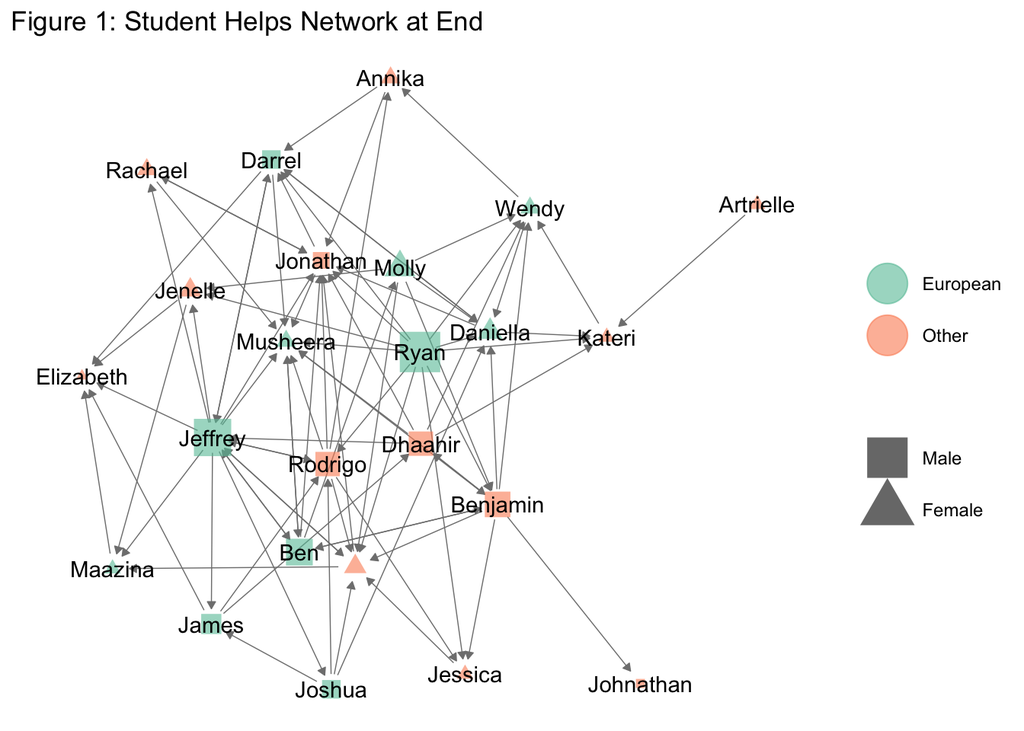

The second graph is the social networks around the same time with nodes sized by out-degree centrality as well (how many people they socialize with). The attribute and network patterns indicate that offline personal relationships are very different from the online helps network in Figure 2:

- The size of the nodes and the European/non-European male/female distinctions all appear to vary less.
- Many of the students that are on the fringes of Figure 1 are more connected and thus more centrally located in Figure 2.

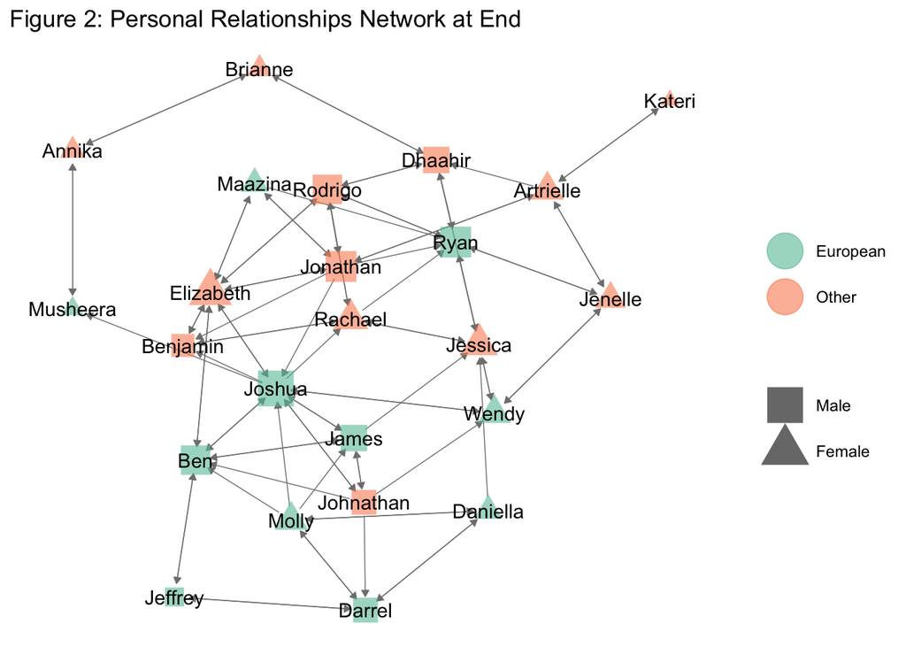

### Modelling & Findings

To test my hypotheses, I modeled the network as a Dynamic Network Actor-Oriented Model (DyNAM) using [Goldfish](https://github.com/snlab-ch/goldfish#readme). DyNAMs are useful for networks with time-stamped interactions, and enable me to focus my scope. My project is about explaining who *gives* help, as opposed to who *receives* help, and DyNAMs enable me to consider just one of these by modeling the network “rate function” (sender) separately from the “choice function” (receiver).

Models 1 and 2 were built using backward elimination. Models 3 and 4 incorporate “window effects” to evaluate whether more recent interactions were explaining who helps, settling on a 45 minute window. For more on DyNAMs see [Stadtfeld, Hollway, and Block, 2017.](https://journals.sagepub.com/doi/full/10.1177/0081175017709295)

The table below compares the results from the four models. Some results are consistent with my predictions, but many are surprising.

Determinants of Helping Peers Over Slack

|  | Full Model | Trim Model | Full Window Model | Trim Window Model |
| --- | --- | --- | --- | --- |
| Intercept | -14.668 *** | -15.164 *** | -14.999 *** | -15.355 *** |
|  | (0.553) | (0.282) | (0.316) | (0.217) |
| H1: In-degree Helps | -0.056 |  | -0.076 |  |
|  | (0.052) |  | (0.053) |  |
| H2: Out-degree Helps | 0.089 ** | 0.127 *** | 0.110 *** | 0.103 *** |
|  | (0.032) | (0.029) | (0.031) | (0.030) |
| In-degree Relates | 0.090 |  |  |  |
|  | (0.081) |  |  |  |
| Out-degree Relates | -0.167 * | -0.077 | -0.140 |  |
|  | (0.075) | (0.058) | (0.074) |  |
| Ego Altruistic | -0.435 |  |  |  |
|  | (0.238) |  |  |  |
| Ego IHEID Familiarity | 0.080 |  |  |  |
|  | (0.206) |  |  |  |
| Ego European | 0.642 ** | 0.557 ** | 0.498 * | 0.570 ** |
|  | (0.230) | (0.196) | (0.199) | (0.197) |
| Ego Knows R | 0.049 |  |  |  |
|  | (0.235) |  |  |  |
| Ego Collaborate | -0.408 |  |  |  |
|  | (0.238) |  |  |  |
| Ego Male | 1.103 *** | 1.071 *** | 0.963 *** | 1.014 *** |
|  | (0.271) | (0.239) | (0.249) | (0.229) |
| In-degree Helps 45 min Window |  |  | 1.985 *** | 1.875 *** |
|  |  |  | (0.388) | (0.385) |
| Out-degree Helps 45 min Window |  |  | 2.153 *** | 2.182 *** |
|  |  |  | (0.186) | (0.185) |
| *** p < 0.001; ** p < 0.01; * p < 0.05. |  |  |  |  |

**Results analysis and key takeaways:**

- We find *negative* support for **$H_1$**. Those who need help may be less able to help others. (See last bullet point for nuance.)
- There is strong support for **$H_2$**; helpers keep helping.
- We find a significant positive association between **European culture** and helping.[^2]
- Surprisingly, the model did *not* find significant relationships for other peer support predictors theorized by the literature. **Altruism** may be negatively associated because students knew their online engagement was factored into final grades. **Social Trust** may be negatively associated because students get help from students they know through other means of communication.
- Of the additional control variables, we find strong support for **men** being more likely than women to help.
- However, neither **popularity**, preferring **group work**, nor **knowledge of R** had a statistically significant relationship—-nor did any other network variables drawn from the offline social relationships network.
- There is a significant window effect, as a couple network centrality effects that otherwise didn’t show an association, became significant predictors.[^3] Notably, **people who were helped within the last 45 minutes** became positively associated with helping, providing support for $H_1$ for recent interactions only. This could be because they had learned something new and were now equipped to pass it on, perhaps within the same thread.

An analysis of the waiting time (between helps to peers) reinforces these findings. Across all students the average time between helps was about 44 days. For a non-European woman that has helped 3 others already their time between helps drops to 30 hours. However, for a European man, their expected response time is predicted to be much less: 19 hours.

In the end, the model with the lowest Akaike Information Criterion (AIC), Model 4, was selected as the best model given the variables considered.

Model AIC Comparison

|  | AIC |
| --- | --- |
| Model 1: Full | 3734 |
| Model 2: Trim | 3734 |
| Model 3: Full Window | 3678 |
| Model 4: Trim Window (Selected) | 3665 |

DyNAMs diagnostics are in development, but it is almost certain that adjustments would need to be made before reaching any conclusions. For instance, Figure 3 shows the distribution of helps is right-skewed with extreme outliers. In addition, the few number of ties (126) and significant variations in volume of online activity over time might also undermine any conclusions. These issues might be mitigated by collecting more data over a longer period of time, and transforming the data to reduce the influence of outliers.

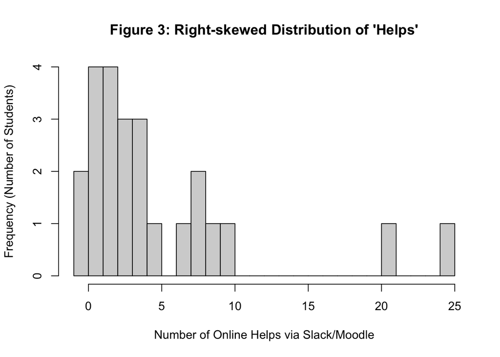

### Conclusion

Network effects do appear to have explanatory power for peer support online, as do attributes including gender and culture. Surprisingly, we found that, if anything, altruism, social relationships offline, and preference for working in groups were negatively associated with helping others. Perhaps the structure of online communication–such as threads–may play a significant role in shaping online networks. At the same time, other factors, including the demographic makeup of the class and the incentives for participation could be impacting the results. Future research could repeat this study for different social networks classes in IHEID and other graduate schools across multiple batches. Studies should also theorize the structural “features” that matter, for instance by comparing interactions within threads to those outside of threads. In general, however, this preliminary analysis provides evidence that social network theories should be considered in future research on online peer learning, and that DyNAMs do provide a promising methodological toolkit for doing so.

[^1]: The names are randomly generated to protect the identity of the students.
[^2]: Local/International and Global Northern/Southern were not significant and thus not included in the summary table.
[^3]: Only for the helps network. The offline relationship network effects were not statistically significant and thus excluded from the summary table.